# EasyVisa_Full_Code_BabatundeAdebiyi (3)

### Model building with original data

```python
models = []  # Empty list to store all the models

# Appending models into the list
models.append(("Bagging", BaggingClassifier(random_state=1)))
models.append(("Random_forest",RandomForestClassifier(random_state=1))) # Random Forest Classifier with random_state = 1
models.append(("GradBoost", GradientBoostingClassifier(random_state=1))) # GradientBoosting with randon state =1
models.append(("Adaboost", AdaBoostClassifier(random_state =1))) # AdaBoost Classifier with random_state = 1
models.append(("Xgboost", XGBClassifier(random_state=1, eval_metric="logloss")))
models.append(("dtree", DecisionTreeClassifier(random_state=1))) ## Decision Tree Classifier with random_state =1

Result01 = []  # Empty list to store all model's CV scores
names = []  # Empty list to store name of the models


# loop through all models to get the mean cross validated score
print("\n" "F1_Score Cross-Validation performance on training dataset:" "\n")

for i, model in models:
    kfold = StratifiedKFold(
        n_splits= 10, shuffle=True, random_state=1
    )  # use 10 split for for about 13k data train data set.
    cv_result = cross_val_score(
        estimator=model, X=X_train, y=y_train, scoring = scorer,cv=kfold
    )
    Result01.append(cv_result)
    names.append(i)
    print("{}: {}".format(i, cv_result.mean()))

print("\n" "F1_Score Validation Performance:" "\n")

for i, model in models:
    model.fit(X_train, y_train) ##  fit the model on X_train and y_train

    scores = f1_score(y_val, model.predict(X_val))
     ## define the metric function name.
    print("{}: {}".format(i, scores))
```

```
F1_Score Cross-Validation performance on training dataset:

Bagging: 0.7798647693190441
Random_forest: 0.806338492627194
GradBoost: 0.8257618831409754
Adaboost: 0.8208392888497575
Xgboost: 0.8106863523274186
dtree: 0.7446484806780492

F1_Score Validation Performance:

Bagging: 0.7827338129496403
Random_forest: 0.7986330844196937
GradBoost: 0.822266107134041
Adaboost: 0.8179521116592468
Xgboost: 0.8052494738145352
dtree: 0.7381519724649193
```

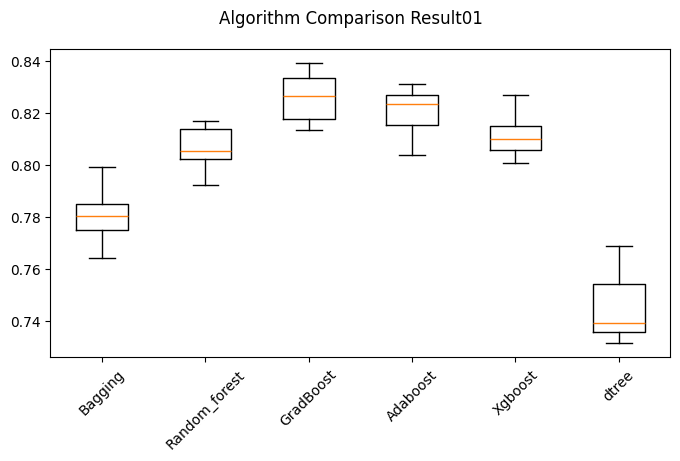

```python
# Visualizing The F1_Score CV scores with box plot for all models defined above
fig = plt.figure(figsize=(8, 4))

fig.suptitle("Algorithm Comparison Result01")
ax = fig.add_subplot(111)

plt.boxplot(Result01)
ax.set_xticklabels(names)
plt.xticks(rotation=45)
plt.show()
```

```python
#Checking RECALL VALUES - But will only use F1_Score
models = []  # Empty list to store all the models

# Appending models into the list
models.append(("Bagging", BaggingClassifier(random_state=1)))
models.append(("Random_forest",RandomForestClassifier(random_state=1))) # Random Forest Classifier with random_state = 1
models.append(("GradBoost", GradientBoostingClassifier(random_state=1))) # GradientBoosting with randon state =1
models.append(("Adaboost", AdaBoostClassifier(random_state =1))) # AdaBoost Classifier with random_state = 1
models.append(("Xgboost", XGBClassifier(random_state=1, eval_metric="logloss")))
models.append(("dtree", DecisionTreeClassifier(random_state=1))) ## Decision Tree Classifier with random_state =1

Result01 = []  # Empty list to store all model's CV scores
names = []  # Empty list to store name of the models


# loop through all models to get the mean cross validated score
print("\n" "Recall_Cross-Validation performance on training dataset:" "\n")

for i, model in models:
    kfold = StratifiedKFold(
        n_splits= 10, shuffle=True, random_state=1
    )  # use 10 split for for about 13k data train data set.
    cv_result = cross_val_score(
        estimator=model, X=X_train, y=y_train, scoring = scorer_rec,cv=kfold
    )
    Result01.append(cv_result)
    names.append(i)
    print("{}: {}".format(i, cv_result.mean()))

print("\n" "Recall_Validation Performance:" "\n")

for i, model in models:
    model.fit(X_train, y_train) ##  fit the model on X_train and y_train

    scores = recall_score(y_val, model.predict(X_val))
     ## define the metric function name.
    print("{}: {}".format(i, scores))
```

```
Recall_Cross-Validation performance on training dataset:

Bagging: 0.7843048467949826
Random_forest: 0.8400490015557243
GradBoost: 0.8788889974472094
Adaboost: 0.8929918506103901
Xgboost: 0.8554967670497107
dtree: 0.7417782103409316

Recall_Validation Performance:

Bagging: 0.7814050665970227
Random_forest: 0.8239749281796814
GradBoost: 0.8699399320971533
Adaboost: 0.8876991381561765
Xgboost: 0.849307913293288
dtree: 0.728127448419953
```

```python
#Checking PRECISION VALUES - But will only use F1_Score
models = []  # Empty list to store all the models

# Appending models into the list
models.append(("Bagging", BaggingClassifier(random_state=1)))
models.append(("Random_forest",RandomForestClassifier(random_state=1))) # Random Forest Classifier with random_state = 1
models.append(("GradBoost", GradientBoostingClassifier(random_state=1))) # GradientBoosting with randon state =1
models.append(("Adaboost", AdaBoostClassifier(random_state =1))) # AdaBoost Classifier with random_state = 1
models.append(("Xgboost", XGBClassifier(random_state=1, eval_metric="logloss")))
models.append(("dtree", DecisionTreeClassifier(random_state=1))) ## Decision Tree Classifier with random_state =1

Result01 = []  # Empty list to store all model's CV scores
names = []  # Empty list to store name of the models


# loop through all models to get the mean cross validated score
print("\n" "Precision_Cross-Validation performance on training dataset:" "\n")

for i, model in models:
    kfold = StratifiedKFold(
        n_splits= 10, shuffle=True, random_state=1
    )  # use 10 split for for about 13k data train data set.
    cv_result = cross_val_score(
        estimator=model, X=X_train, y=y_train, scoring = scorer_prec,cv=kfold
    )
    Result01.append(cv_result)
    names.append(i)
    print("{}: {}".format(i, cv_result.mean()))

print("\n" "Precision_Validation Performance:" "\n")

for i, model in models:
    model.fit(X_train, y_train) ##  fit the model on X_train and y_train

    scores =precision_score(y_val, model.predict(X_val))
     ## define the metric function name.
    print("{}: {}".format(i, scores))
```

```
Precision_Cross-Validation performance on training dataset:

Bagging: 0.7755591063883327
Random_forest: 0.7752879531640725
GradBoost: 0.7787601336158843
Adaboost: 0.7595527148655858
Xgboost: 0.770404184808725
dtree: 0.7478053710795395

Precision_Validation Performance:

Bagging: 0.7840670859538784
Random_forest: 0.774803536345776
GradBoost: 0.7795459864263983
Adaboost: 0.7583668005354752
Xgboost: 0.7655367231638418
dtree: 0.7484563758389262
```

### Model Building with oversampled data

##### Expectation is the tags with 'N" or "0' should be minority uptot about 1/3 of the population

```python
print("Before OverSampling, counts of label '1': {}".format(sum(y_train == 1)))
print("Before OverSampling, counts of label '0': {} \n".format(sum(y_train == 0)))

# Synthetic Minority Over Sampling Technique
smt=SMOTE(sampling_strategy=1, k_neighbors=5, random_state=1) ##  k-nearest neighbors and sampling using 1)
X_train_ovs, y_train_ovs = smt.fit_resample(X_train, y_train)


print("After OverSampling, counts of label '1': {}".format(sum(y_train_ovs == 1)))
print("After OverSampling, counts of label '0': {} \n".format(sum(y_train_ovs == 0)))


print("After OverSampling, the shape of train_X: {}".format(X_train_ovs.shape))
print("After OverSampling, the shape of train_y: {} \n".format(y_train_ovs.shape))
```

```
Before OverSampling, counts of label '1': 8934
Before OverSampling, counts of label '0': 4443

After OverSampling, counts of label '1': 8934
After OverSampling, counts of label '0': 8934

After OverSampling, the shape of train_X: (17868, 28)
After OverSampling, the shape of train_y: (17868,)
```

```python
models = []  # Empty list to store all the models

# Appending models into the list
models.append(("Bagging", BaggingClassifier(random_state=1)))
models.append(("Random_forest",RandomForestClassifier(random_state=1))) # Random Forest Classifier with random_state = 1
models.append(("GradBoost", GradientBoostingClassifier(random_state=1))) # GradientBoosting with randon state =1
models.append(("Adaboost", AdaBoostClassifier(random_state =1))) # AdaBoost Classifier with random_state = 1
models.append(("Xgboost", XGBClassifier(random_state=1, eval_metric="logloss")))
models.append(("dtree", DecisionTreeClassifier(random_state=1))) ## Decision Tree Classifier with random_state =1

Result02 = []  # Empty list to store all model's CV scores
names = []  # Empty list to store name of the models


# loop through all models to get the mean cross validated score
print("\n" "F1_Score Cross-Validation performance on Oversampled training dataset:" "\n")

for i, model in models:
    kfold = StratifiedKFold(
        n_splits= 10, shuffle=True, random_state=1
    )  # use 10 split for for about 13k data train data set.
    cv_result = cross_val_score(
        estimator=model, X=X_train_ovs, y=y_train_ovs, scoring = scorer,cv=kfold
    )
    Result02.append(cv_result)
    names.append(i)
    print("{}: {}".format(i, cv_result.mean()))

print("\n" "F1_score Validation Performance:" "\n")

for i, model in models:
    model.fit(X_train_ovs, y_train_ovs) ##  fit the model on oversampled X_train and y_train

    scores = f1_score(y_val, model.predict(X_val))
     ## define the metric function name.
    print("{}: {}".format(i, scores))
```

```
F1_Score Cross-Validation performance on Oversampled training dataset:

Bagging: 0.7785058238102628
Random_forest: 0.8045427642252447
GradBoost: 0.8197155104409319
Adaboost: 0.7992673642672691
Xgboost: 0.8123840853841082
dtree: 0.7427220552275827

F1_score Validation Performance:

Bagging: 0.771744860305746
Random_forest: 0.7971142893304645
GradBoost: 0.8213445586232512
Adaboost: 0.8156687740176026
Xgboost: 0.8008003001125422
dtree: 0.7369395582594895
```

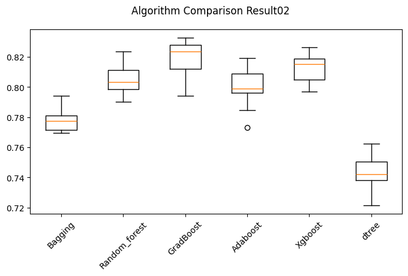

```python
# Visualizing The F1_Score CV scores with box plot for all models defined above
fig = plt.figure(figsize=(8, 4))

fig.suptitle("Algorithm Comparison Result02")
ax = fig.add_subplot(111)

plt.boxplot(Result02)
ax.set_xticklabels(names)
plt.xticks(rotation=45)
plt.show()
```

### Model Building with undersampled data

```python
rus = RandomUnderSampler(random_state=1, sampling_strategy=1)
X_train_uns, y_train_uns = rus.fit_resample(X_train, y_train)


print("Before UnderSampling, counts of label '1': {}".format(sum(y_train == 1)))
print("Before UnderSampling, counts of label '0': {} \n".format(sum(y_train == 0)))


print("After UnderSampling, counts of label '1': {}".format(sum(y_train_uns == 1)))
print("After UnderSampling, counts of label '0': {} \n".format(sum(y_train_uns == 0)))


print("After UnderSampling, the shape of train_X: {}".format(X_train_uns.shape))
print("After UnderSampling, the shape of train_y: {} \n".format(y_train_uns.shape))
```

```
Before UnderSampling, counts of label '1': 8934
Before UnderSampling, counts of label '0': 4443

After UnderSampling, counts of label '1': 4443
After UnderSampling, counts of label '0': 4443

After UnderSampling, the shape of train_X: (8886, 28)
After UnderSampling, the shape of train_y: (8886,)
```

```python
models = []  # Empty list to store all the models

# Appending models into the list
models.append(("Bagging", BaggingClassifier(random_state=1)))
models.append(("Random_forest",RandomForestClassifier(random_state=1))) # Random Forest Classifier with random_state = 1
models.append(("GradBoost", GradientBoostingClassifier(random_state=1))) # GradientBoosting with randon state =1
models.append(("Adaboost", AdaBoostClassifier(random_state =1))) # AdaBoost Classifier with random_state = 1
models.append(("Xgboost", XGBClassifier(random_state=1, eval_metric="logloss")))
models.append(("dtree", DecisionTreeClassifier(random_state=1))) ## Decision Tree Classifier with random_state =1

Result03 = []  # dummy list for model's CV scores
names = []  # dummy list name of the models


# loop through all models to get the mean cross validated score
print("\n" "F1_Csore Cross-Validation performance on Undersampled training dataset:" "\n")

for i, model in models:
    kfold = StratifiedKFold(
        n_splits= 10, shuffle=True, random_state=1
    )  # use 10 split for for about 13k data train data set.
    cv_result = cross_val_score(
        estimator=model, X=X_train_uns, y=y_train_uns, scoring = scorer,cv=kfold
    )
    Result03.append(cv_result)
    names.append(i)
    print("{}: {}".format(i, cv_result.mean()))

print("\n" "F1_score Validation Performance:" "\n")

for i, model in models:
    model.fit(X_train_uns, y_train_uns) ##  fit the model on undersampled X_train and y_train

    scores = f1_score(y_val, model.predict(X_val))
     ##define the metric function name.
    print("{}: {}".format(i, scores))
```

```
F1_Csore Cross-Validation performance on Undersampled training dataset:

Bagging: 0.65111304532455
Random_forest: 0.6855304200091094
GradBoost: 0.7094406430938845
Adaboost: 0.7013934524811268
Xgboost: 0.6881051137805063
dtree: 0.6291233427484757

F1_score Validation Performance:

Bagging: 0.6999554168524298
Random_forest: 0.7307692307692307
GradBoost: 0.7696408529741863
Adaboost: 0.7611111111111111
Xgboost: 0.7466478475652788
dtree: 0.6906327634078621
```

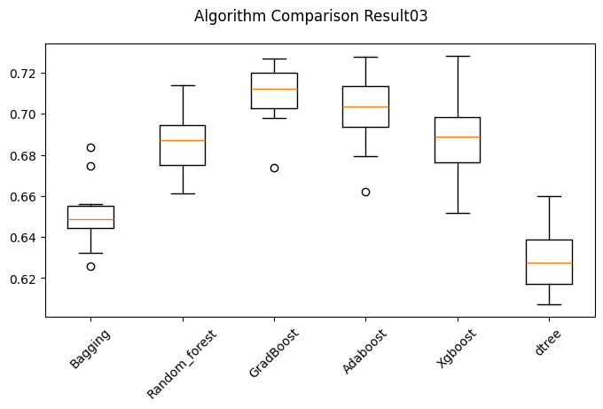

```python
# Visualizing The F1_Score CV scores with box plot for all models defined above
fig = plt.figure(figsize=(8, 4))

fig.suptitle("Algorithm Comparison Result03")
ax = fig.add_subplot(111)

plt.boxplot(Result03)
ax.set_xticklabels(names)
plt.xticks(rotation=45)
plt.show()
```

## Hyperparameter Tuning

### Tuning ADABOOST Using Oversampled Data

```python
!pip install --upgrade numpy #update numpy

# defining model
Model = AdaBoostClassifier(random_state=1)

# Parameter grid to pass in RandomSearchCV
param_grid = {
    "n_estimators": [50,100,150,200], ## n_estimators
    "learning_rate": [0.05,0.1, 0.5], ## learning rate.
    "estimator": [DecisionTreeClassifier(max_depth=1, random_state=1), DecisionTreeClassifier(max_depth=2, random_state=1), DecisionTreeClassifier(max_depth=3, random_state=1),
    ]
}
#kfold = StratifiedKFold(n_splits= 10, shuffle=True, random_state=1)

#Calling RandomizedSearchCV
randomized_cv = RandomizedSearchCV(estimator=Model, param_distributions=param_grid, n_iter=50, n_jobs = -1, scoring=scorer, cv=5, random_state=1)  ## cv parameter

#Fitting parameters in RandomizedSearchCV
randomized_cv.fit(X_train_ovs, y_train_ovs) ## CV on oversampled data

print("Best parameters are {} with CV score={}:" .format(randomized_cv.best_params_,randomized_cv.best_score_))
```

```
Best parameters are {'n_estimators': 150, 'learning_rate': 0.5, 'estimator': DecisionTreeClassifier(max_depth=3, random_state=1)} with CV score=0.8116450527215567:
```

```python
## set the best parameters.
tuned_ada_ovs = AdaBoostClassifier(
    n_estimators=150, learning_rate= 0.5, estimator= DecisionTreeClassifier(max_depth=3, random_state=1)
)

tuned_ada_ovs.fit(X_train_ovs, y_train_ovs)
```

```
AdaBoostClassifier(estimator=DecisionTreeClassifier(max_depth=3,
                                                    random_state=1),
                   learning_rate=0.5, n_estimators=150)
```

```python
ada_ovs_train_perf = model_performance_classification_sklearn(tuned_ada_ovs, X_train_ovs,y_train_ovs)
ada_ovs_train_perf
```

|  | Accuracy | Recall | Precision | F1 |
| --- | --- | --- | --- | --- |
| 0 | 0.810443 | 0.852474 | 0.786371 | 0.818089 |

```python
##check the model performance for validation data.
ada_ovs_val_perf = model_performance_classification_sklearn(tuned_ada_ovs,X_val,y_val)
ada_ovs_val_perf
```

|  | Accuracy | Recall | Precision | F1 |
| --- | --- | --- | --- | --- |
| 0 | 0.740101 | 0.83416 | 0.788837 | 0.810866 |

### Tuning Random forest using undersampled data

```python
# defining model
Model = RandomForestClassifier(random_state=1)

# Parameter grid to pass in RandomSearchCV
param_grid = {
    "n_estimators": [20,50,100,150,200], ## number of estimators.
    "min_samples_leaf": np.arange(1,11), ## minimum number of samples in the leaf node.
    "max_features": [np.arange(1,X_train_uns.shape[1] +1,2),'sqrt'], ## maximum number of features.
    "max_samples":np.arange(0.5,1.1,0.1),
    "class_weight" : ['balanced', 'balanced_subsample'],
    "max_depth":np.arange(3,4,5),
    "min_impurity_decrease":[0.001, 0.002, 0.003]
    }


#Calling RandomizedSearchCV
randomized_cv = RandomizedSearchCV(estimator=Model, param_distributions=param_grid, n_iter=50, n_jobs = -1, scoring=scorer, cv=5, random_state=1) ## the cv parameter

#Fitting parameters in RandomizedSearchCV
randomized_cv.fit(X_train_uns,y_train_uns) ## fit the model on under sampled data

print("Best parameters are {} with CV score={}:" .format(randomized_cv.best_params_,randomized_cv.best_score_)) ## set best parameter.
```

```
Best parameters are {'n_estimators': 200, 'min_samples_leaf': np.int64(5), 'min_impurity_decrease': 0.002, 'max_samples': np.float64(0.8999999999999999), 'max_features': 'sqrt', 'max_depth': np.int64(3), 'class_weight': 'balanced'} with CV score=0.7044550162492684:
```

```python
# define the best model
tuned_rf_uns = RandomForestClassifier(
    max_features='sqrt',
    random_state=1,
    max_samples=0.8999,
    n_estimators=200,
    min_samples_leaf=5,
    max_depth = 3,
    min_impurity_decrease=0.002,
    class_weight='balanced',
)

tuned_rf_uns.fit(X_train_uns, y_train_uns)
```

```
RandomForestClassifier(class_weight='balanced', max_depth=3, max_samples=0.8999,
                       min_impurity_decrease=0.002, min_samples_leaf=5,
                       n_estimators=200, random_state=1)
```

```python
rf_uns_train_perf = model_performance_classification_sklearn(
    tuned_rf_uns, X_train_uns, y_train_uns
)
rf_uns_train_perf
```

|  | Accuracy | Recall | Precision | F1 |
| --- | --- | --- | --- | --- |
| 0 | 0.700765 | 0.698177 | 0.70181 | 0.699989 |

```python
## print the model performance on the validation data.
rf_uns_val_perf = model_performance_classification_sklearn(tuned_rf_uns, X_val, y_val)
rf_uns_val_perf
```

|  | Accuracy | Recall | Precision | F1 |
| --- | --- | --- | --- | --- |
| 0 | 0.698413 | 0.691564 | 0.828536 | 0.753879 |

### Tuning with Gradient boosting with oversampled data

```python
%%time

# defining model
Model = GradientBoostingClassifier(random_state=1)

## the hyper parameters.
param_grid={"n_estimators": np.arange(50,300,50),
            "learning_rate": [0.2,0.4,0.6, 0.8],
            "subsample":[0.6,0.8,1.0],
            "max_features":['sqrt','log2','none']}

## set the cv parameter.
randomized_cv = RandomizedSearchCV(estimator=Model, param_distributions=param_grid, scoring=scorer, n_iter=50, n_jobs = -1, cv=5, random_state=1)

#Fitting parameters in RandomizedSearchCV
randomized_cv.fit(X_train_ovs, y_train_ovs)

print("Best parameters are {} with CV score={}:" .format(randomized_cv.best_params_,randomized_cv.best_score_))
```

```
Best parameters are {'subsample': 1.0, 'n_estimators': np.int64(200), 'max_features': 'sqrt', 'learning_rate': 0.2} with CV score=0.8179523114280457:
CPU times: user 4.5 s, sys: 286 ms, total: 4.78 s
Wall time: 2min 32s
```

```python
## define the best model.
tuned_gradboost_ovs = GradientBoostingClassifier(
    max_features='sqrt',
    random_state=1,
    learning_rate=0.2,
    n_estimators=200,
    subsample=1
)

tuned_gradboost_ovs.fit(X_train_ovs, y_train_ovs)
```

```
GradientBoostingClassifier(learning_rate=0.2, max_features='sqrt',
                           n_estimators=200, random_state=1, subsample=1)
```

```python
gradboost_ovs_train_perf = model_performance_classification_sklearn(
    tuned_gradboost_ovs, X_train_ovs, y_train_ovs
)
gradboost_ovs_train_perf
```

|  | Accuracy | Recall | Precision | F1 |
| --- | --- | --- | --- | --- |
| 0 | 0.824659 | 0.877323 | 0.793722 | 0.833431 |

```python
gradboost_ovs_val_perf = model_performance_classification_sklearn(
    tuned_gradboost_ovs, X_val, y_val
)
gradboost_ovs_val_perf
```

|  | Accuracy | Recall | Precision | F1 |
| --- | --- | --- | --- | --- |
| 0 | 0.74359 | 0.85192 | 0.783193 | 0.816112 |

### Tuning XGBoost using oversampled data

```python
%%time

# defining model
Model = XGBClassifier(random_state=1,eval_metric='logloss')

## define the hyperparameters
param_grid={'n_estimators':[150,275,25],
            'scale_pos_weight':[1,5,10,20],
            'learning_rate':[0.05,0.1,0.2,0.4],
            'gamma':[0,0.1,0.3,0.5],
            'subsample':[0.6,0.8,1.0,1.2]}

## set the cv parameter
randomized_cv = RandomizedSearchCV(estimator=Model, param_distributions=param_grid, n_iter=50, n_jobs = -1, scoring=scorer, cv=5, random_state=1)

#Fitting parameters in RandomizedSearchCV
randomized_cv.fit(X_train_ovs,y_train_ovs)## model on over sampled data

print("Best parameters are {} with CV score={}:" .format(randomized_cv.best_params_,randomized_cv.best_score_))
```

```
Best parameters are {'subsample': 1.0, 'scale_pos_weight': 5, 'n_estimators': 150, 'learning_rate': 0.4, 'gamma': 0.5} with CV score=0.8248406340332901:
CPU times: user 4.04 s, sys: 192 ms, total: 4.23 s
Wall time: 1min 18s
```

```python
## define the best model
xgb_ovs = XGBClassifier(
    random_state=1,
    eval_metric='logloss',
    subsample=1.0,
    scale_pos_weight=5,
    n_estimators=150,
    learning_rate=0.4,
    gamma=0.5,
)

xgb_ovs.fit(X_train_ovs, y_train_ovs)
```

```
XGBClassifier(base_score=None, booster=None, callbacks=None,
              colsample_bylevel=None, colsample_bynode=None,
              colsample_bytree=None, device=None, early_stopping_rounds=None,
              enable_categorical=False, eval_metric='logloss',
              feature_types=None, gamma=0.5, grow_policy=None,
              importance_type=None, interaction_constraints=None,
              learning_rate=0.4, max_bin=None, max_cat_threshold=None,
              max_cat_to_onehot=None, max_delta_step=None, max_depth=None,
              max_leaves=None, min_child_weight=None, missing=nan,
              monotone_constraints=None, multi_strategy=None, n_estimators=150,
              n_jobs=None, num_parallel_tree=None, random_state=1, ...)
```

```python
xgb_ovs_train_perf = model_performance_classification_sklearn(
    xgb_ovs, X_train_ovs, y_train_ovs)
xgb_ovs_train_perf
```

|  | Accuracy | Recall | Precision | F1 |
| --- | --- | --- | --- | --- |
| 0 | 0.809716 | 0.998993 | 0.724667 | 0.84 |

```python
## print the model performance on the validation data.
xgb_ovs_val_perf = model_performance_classification_sklearn(xgb_ovs,X_val,y_val)
xgb_ovs_val_perf
```

|  | Accuracy | Recall | Precision | F1 |
| --- | --- | --- | --- | --- |
| 0 | 0.703297 | 0.97075 | 0.700528 | 0.813793 |

## Model Performances

### Model performance comparison and choosing the final model

```python
# training performance comparison

models_train_comp_df = pd.concat(
    [
        gradboost_ovs_train_perf.T,
        xgb_ovs_train_perf.T,
        ada_ovs_train_perf.T,
        rf_uns_train_perf.T,
    ],
    axis=1,
)
models_train_comp_df.columns = [
    "Gradient Boosting tuned with oversampled data",
    "XGBoost tuned with oversampled data",
    "AdaBoost tuned with oversampled data",
    "Random forest tuned with undersampled data",
]
print("Training performance comparison:")
models_train_comp_df
```

```
Training performance comparison:
```

|  | Gradient Boosting tuned with oversampled data | XGBoost tuned with oversampled data | AdaBoost tuned with oversampled data | Random forest tuned with undersampled data |
| --- | --- | --- | --- | --- |
| Accuracy | 0.824659 | 0.809716 | 0.810443 | 0.700765 |
| Recall | 0.877323 | 0.998993 | 0.852474 | 0.698177 |
| Precision | 0.793722 | 0.724667 | 0.786371 | 0.701810 |
| F1 | 0.833431 | 0.840000 | 0.818089 | 0.699989 |

```python
# validation performance comparison

models_val_comp_df = pd.concat(
    [
        gradboost_ovs_val_perf.T,
        xgb_ovs_val_perf.T,
        ada_ovs_val_perf.T,
        rf_uns_val_perf.T,
    ],
    axis=1,
)
models_val_comp_df.columns = [
    "Gradient Boosting tuned with oversampled data",
    "XGBoost tuned with oversampled data",
    "AdaBoost tuned with oversampled data",
    "Random forest tuned with undersampled data",
]
print("Validation performance comparison:")
models_val_comp_df
```

```
Validation performance comparison:
```

|  | Gradient Boosting tuned with oversampled data | XGBoost tuned with oversampled data | AdaBoost tuned with oversampled data | Random forest tuned with undersampled data |
| --- | --- | --- | --- | --- |
| Accuracy | 0.743590 | 0.703297 | 0.740101 | 0.698413 |
| Recall | 0.851920 | 0.970750 | 0.834160 | 0.691564 |
| Precision | 0.783193 | 0.700528 | 0.788837 | 0.828536 |
| F1 | 0.816112 | 0.813793 | 0.810866 | 0.753879 |

## Actionable Insights and Recommendations

### F1- Score WIll be used to make the decision

### Candidates for consideration

#### (1)GradBoost with no tuning, no OVS and no UNS

#######F1_Test = 0.826; F1_Val = 0.822

#### (2)GradBoost with OVS Tuning

#######F1_Test = 0.833; F1_Val = 0.816

#### (3)AdaBoost with OVS tuning

#######F1_Test = 0.818; F1_Val = 0.811

#### (4)XGBoost With OVS tuning

#######F1_Test = 0.840; F1_Val = 0.814

#######Conclusion: The 4 above will perform well but I will eliminate option_4(XGBOOST with OVS) due to slight risk of overfitting. I will choose option_2 (GradBoost with Oversampling), because the F1_val ~0.82 is higher and close to its F1_test. Option(1) - was highly considered as well, no concrete reason for not chooisng it

```python
## print the model performance on the test data by the best model.
test_gradboost_ovs = model_performance_classification_sklearn(tuned_gradboost_ovs, X_test,y_test)
test_gradboost_ovs
```

|  | Accuracy | Recall | Precision | F1 |
| --- | --- | --- | --- | --- |
| 0 | 0.741601 | 0.86369 | 0.775153 | 0.81703 |

Performance on Test Data without Data Leak gave 0.817 ~0.82 same as Val (0.82) and close to train data(0.83)

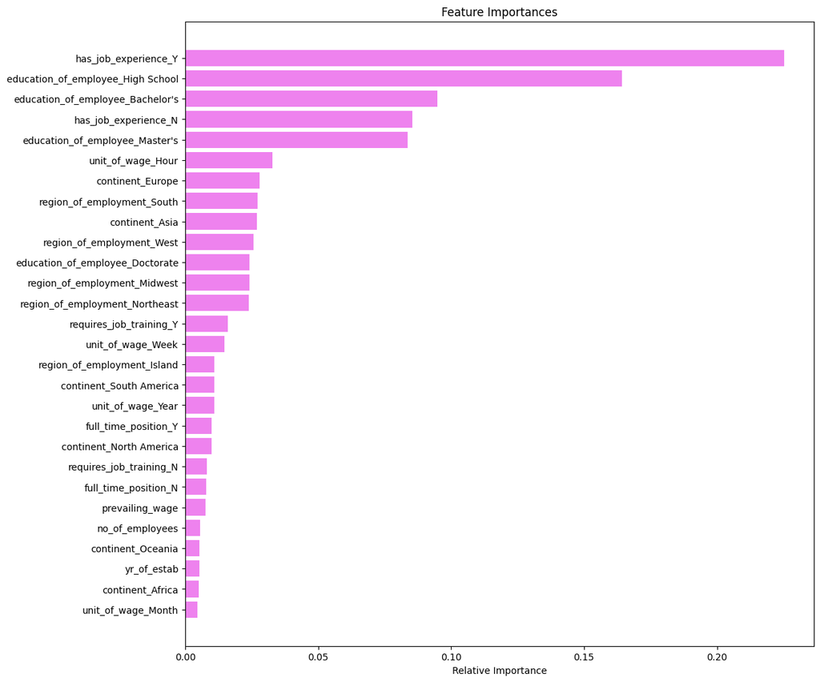

```python
feature_names = X_train.columns
importances = randomized_cv.best_estimator_.feature_importances_ ## feature importances from the best model.
indices = np.argsort(importances)

plt.figure(figsize=(12, 12))
plt.title("Feature Importances")
plt.barh(range(len(indices)), importances[indices], color="violet", align="center")
plt.yticks(range(len(indices)), [feature_names[i] for i in indices])
plt.xlabel("Relative Importance")
plt.show()
```

### Actionable Insights and Recommendations

##### The first 5 features are very importanct factors in decding a Y or N for Visa.

##### The last features from Job traing downward do not play significant role in the decison making

##### While regeion play a mid-level role in the process of deciding the visa grant

##### Lastly there were at least 3 models that could possibly work well and it was slightly diffficult to pick the final candidate

Power Ahead